# CURSO CIENCIA DE DATOS - CLASE 8

Angie Scetta

UTDT, 2022

# INFORMACIÓN GEOGRÁFICA Y MAPAS

## Introducción

En las clases anteriores aprendimos a utilizar RStudio con el fin de explorar, analizar, procesar y visualizar información. Sin embargo, todavía nos queda por delante un tema muy importante a la hora de analizar ciudades y políticas públicas: **Información geográfica y Mapas**.

Concretamente, hoy aprenderemos a **crear diversos mapas que nos permitan visualizar y relacionar datos en el territorio** y en las próximas clases **utilizaremos algunos paquetes/librerías que nos permitan hacer análisis espaciales**.

Pero antes de empezar, ¿A que nos referimos cuando hablamos de **Sistemas de Información Geográfica** o **SIG**? En pocas palabras, los SIG son herramientas informáticas que nos permiten ubicar y analizar un conjunto de datos en lugares específicos del territorio (georreferenciar).

Para poder hacer uso de los SIG necesitamos contar con información geográfica en nuestro dataset. Es decir que, además de la información que puede existir en un dataset tradicional, es necesario que cada registro tenga un componente espacial (partido, barrio, manzana, dirección, intersección de calles, o directamente las coordenadas X e Y).

### Tipos de datos

Para representar estos componentes espaciales existen **2 tipos de datos geográficos**:

1. **Datos vectoriales**, que pueden estar asociados a una base de datos alfanumérica y se representan a partir de coordenadas (X e Y) que generan 3 tipos de geometrías:
- Puntos: x e y de la ubicación
- Líneas: x e y de los puntos de inicio y fin
- Polígonos: x e y de todos los vértices

Por ejemplo, los datos vectoriales pueden representar entidades como hospitales (puntos), avenidas (líneas) y áreas verdes (polígonos).

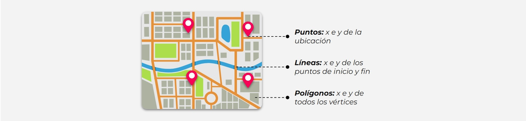

2. **Datos ráster**, que se representan a partir de una “matriz” dividida en múltiples pixeles/celdas del mismo tamaño y con un dato/valor específico asociado. Concretamente, este tipo de dato se suele utilizar para almacenar imágenes (fotos aéreas, imágenes satelitales, etc).

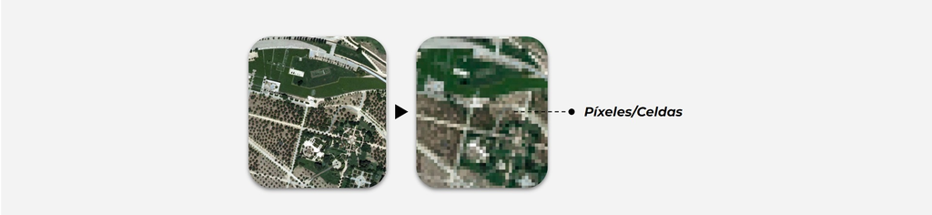

### Formatos de archivos

Ambos tipos de datos geográficos serán guardados en **formatos específicos** de acuerdo al tipo de información y al objetivo que tengan. Los **formatos de archivo** más conocidos y utilizados para almacenar información geográfica son:

- Shapefile (.shp), que es el formato más popular para datos vectoriales. Fue desarrollado por la empresa ESRI y cada archivo solo puede contener un tipo de geometría. Cabe destacar que, este formato se conforma por un conjunto de archivos (.shp, .shx, .dbf, etc) que tienen que existir en la misma carpeta para que funcione correctamente.
- GeoJSON (.geoJSON), que es un formato estándar abierto muy utilizado para datos vectoriales. A diferencia del .shp, se conforma por un único archivo de texto que, al almacenar geometrías complejas su tamaño puede ser muy superior al de un shapefile.
- Comma Separated Values (.csv), que es un formato de texto separado por comas que puede almacenar datos vectoriales en columnas donde indique los pares de coordenadas (puntos) que conformen las diferentes geometrías. Cabe destacar que, el .csv también puede ser un “GeoCSV”, cuanto existe la columna WKT (Well Known Text) que es de tipo String y almacena geometrías. El sistema de coordenadas por defecto es WGS84 (EPSG:4326).
- Keyhole Markup Language (.KML), que es un formato abierto que se originó para datos de Google Earth. Los .KML pueden guardar datos vectoriales, archivos de tipo .kmz, entre otros.
- GeoPackage (.gpkg), que también es un formato abierto que puede contener datos espaciales vectoriales y ráster.
- GeoTIFF (.tif), que es uno de los formatos más populares para almacenar datos ráster. Este tipo de archivo necesita ir acompañado de un .tfw que le dará la referencia geográfica (proyección, sistema de coordenadas, etc) al .tif.

### Representación gráfica: Mapas

Las herramientas que nos permitirán visualizar toda esta información serán los **mapas**, que son nada más y nada menos que representaciones planas, reducidas y simplificadas de la tierra que nos dan la posibilidad cruzar y relacionar datos en el espacio. Es decir que, mantienen una relación ordenada en el traspaso de puntos ubicados en la superficie curva de la tierra a puntos ubicados en la superficie plana de los mapas. Esto es posible a partir del uso de sistemas de coordenadas de referencia y de proyecciones cartográficas.

En R hay varios paquetes de funciones que nos permiten manipular este tipo de información, entre los que se encuentra `sf`, que lo aprenderemos hoy. Cualquier duda siempre pueden [consultar la documentación](https://cran.r-project.org/web/packages/sf/sf.pdf) y/o el [cheat sheet](https://github.com/rstudio/cheatsheets/blob/main/sf.pdf).

Para comenzar, activemos nuestra ya conocida librería tidyverse, e instalemos y activemos `sf`:

```r
#install.packages(tidyverse)
library(tidyverse)
#install.packages(sf)
library(sf)
```

## Análisis de datos espaciales

A continuación trabajaremos con un dataset espacial en formato *geoJSON* que contiene las geometrías correspondientes a todos los partidos de Área Metropolitana de Buenos Aires (AMBA). Pueden descargarlo en el [siguiente link](https://data.world/angie-scetta/partidos-amba-geojson).

*Recomendación: Al descargar el GEOjson deberán moverlo de la carpeta “Descargas” a la carpeta llamada “data” dentro del Proyecto donde están trabajando.*

Para poder cargar nuestros datos espaciales en formato *GEOjson* utilizaremos la función `st_read()` de la siguiente forma:

```r
partidos_amba <- st_read("data/partidos_amba.geojson", stringsAsFactors = TRUE)
```

Veamos que información contiene:

```r
summary(partidos_amba)
```

```
##              nombre   provincia    area_km2               geometry
##  ALMIRANTE BROWN: 1   CABA:15   Min.   :  6.30   MULTIPOLYGON :48
##  AVELLANEDA     : 1   GBA :33   1st Qu.: 17.72   epsg:4326    : 0
##  BERAZATEGUI    : 1             Median : 55.91   +proj=long...: 0
##  BERISSO        : 1             Mean   :140.59
##  COMUNA 1       : 1             3rd Qu.:177.07
##  COMUNA 10      : 1             Max.   :889.49
##  (Other)        :42
```

Las primeras 3 columnas presentan el nombre del partido, la provincia y el área en km2. Estos son datos muy similares a las que seguramente ya venían encontrando en los dataset tradicionales. Sin embargo, aparece una 4ta columna llamada *geometry* que es donde se aloja la geometría de cada uno de los registros. La información de este campo es la que hace que el dataset sea espacial.

Si queda alguna duda, podemos utilizar la función `class()` para ver con que tipo de datos estamos trabajando:

```r
class(partidos_amba)
```

```
## [1] "sf"         "data.frame"
```

Efectivamente partidos_amba es un dataset espacial u objeto del tipo “sf”, que hace referencia a *simple features* por estar compuesto de geometrías bidimensionales (polígono, punto, línea, multipolígono, multipunto, multilínea).

Para poder visualizar toda esta información plasmada en un mapa vamos a utilizar el ya conocido `ggplot()`, pero como en esta oportunidad queremos sumar capas geográficas (sf) trabajaremos con `geom_sf()`. Veamos un ejemplo:

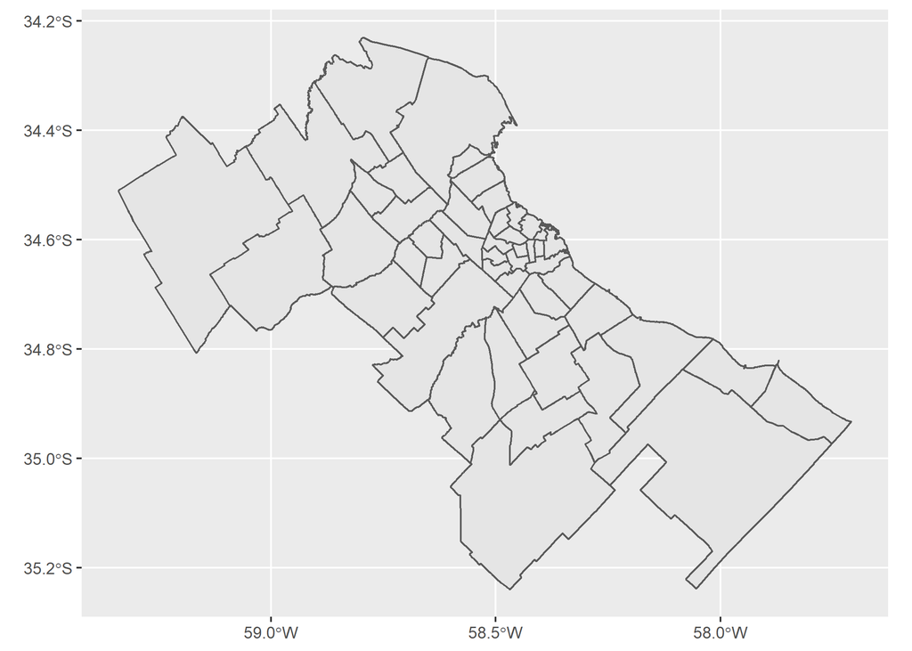

```r
ggplot(partidos_amba)+
  geom_sf()
```

Como habrán notado, la lógica en la estructura del chunk que utilizamos para hacer este mapa es igual a la utilizada para hacer gráficos/visualizaciones (barras, puntos, histograma, etc.), donde dentro del ggplot() asignamos el dataset y luego sumamos la capa a graficar/mapear (en este caso un objeto sf).

En el mapa podemos ver como las geometrías de cada registro del dataset espacial son polígonos que representan los partidos de AMBA. Probemos agregar algún atributo estético `aes()`:

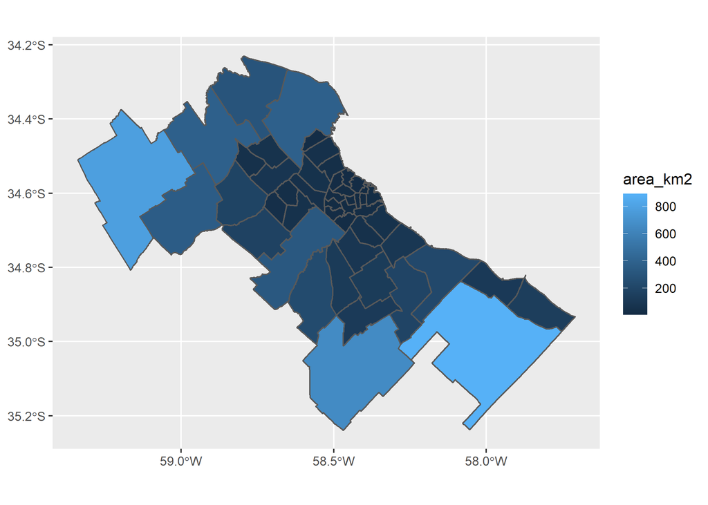

```r
ggplot(partidos_amba)+
  geom_sf(aes(fill=area_km2))
```

Ya tenemos nuestro primer **mapa coroplético**, un tipo de mapa temático donde se colorean las áreas de los polígonos para representar diversos valores de una misma variable (en este caso area_km2).

Ahora probemos ajustando algunas cuestiones estéticas: agreguemos etiquetas (labs) y cambiemos el theme, la paleta (y su escala) y el color del borde de los polígonos.

Cabe destacar que hay 2 tipos de paletas/escalas de color:

1. Las ya establecidas (listas para usar): Brewer, Viridis. En ggplot2 las van a encontrar como scale_fill_viridis_c(), scale_fill_viridis_d(), scale_fill_distiller(), scale_color_distiller() y demás variantes. Pueden ver las opciones de viridis [acá](https://cran.r-project.org/web/packages/viridis/vignettes/intro-to-viridis.html) y las opciones de brewer [acá](https://colorbrewer2.org/).

Las personalizadas, donde podemos elegir todos los colores: Gradiente (scale_fill_gradient()), Manual (scale_fill_manual()). Para obtener un listado de colores pueden ver este [link](http://www.stat.columbia.edu/~tzheng/files/Rcolor.pdf) o bien, utilizar los códigos HEX clásicos.

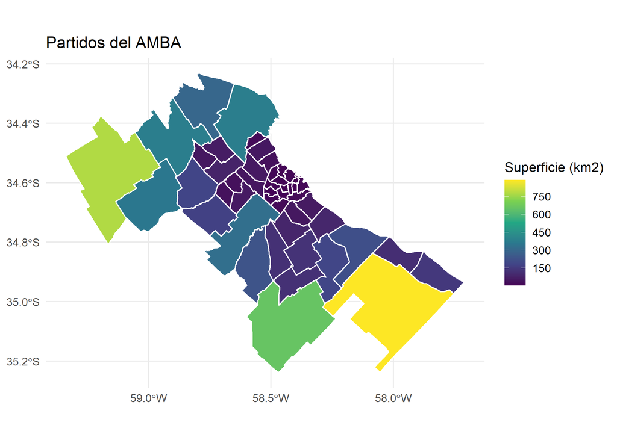

```r
ggplot(partidos_amba)+
  geom_sf(aes(fill=area_km2), color="white")+
  scale_fill_viridis_c(breaks=seq(0, 900, 150))+
  labs(title="Partidos del AMBA",
       fill="Superficie (km2)")+
  theme_minimal()
```

El mapa anterior, si bien quedó bastante lindo, no nos da mucha información, ¿No? Ya que la superficie de los polígonos ya la veíamos por el tamaño de cada uno, entonces además agregarle el valor (en km2) resulta algo redundante.

Si revisamos las columnas, vemos que no tenemos muchas más variables más por mapear así que probemos con “provincia”:

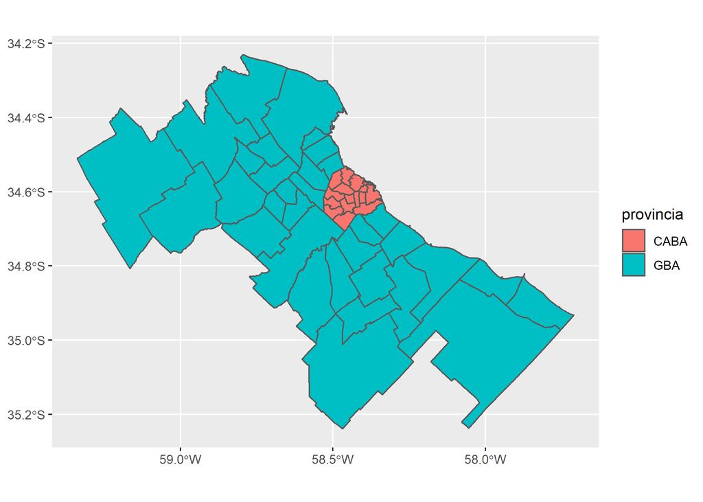

```r
ggplot(partidos_amba)+
  geom_sf(aes(fill=provincia))
```

Bien! Para quienes no conocen el AMBA, puede resultarles muy relevante este mapa, pero a fines estadísticos o de análisis espacial, no aporta demasiada información.

Pero no se preocupen! Que hay una solución para todo! En este caso, podemos usar nuestra creatividad y elegir un dataset tradicional con información a nivel partido y agregarle la data a nuestro dataset espacial.

## Cruce de datos tradicionales y espaciales

Es muy común que a la hora de trabajar con datos no encontremos toda la información que necesitamos en un solo dataset. Frente a esto, lo que se hace es unir/cruzar datos provenientes de diferentes fuentes de información. En este apartado veremos como realizar estos cruces entre datos tradicionales y espaciales.

El paquete `tidyverse` tiene varias funciones que nos permiten unir tablas a partir de una o más variables/columnas en común. Las principales son **full_join(), inner_join(), left_join() y right_join()**, y esquemáticamente lucen así:

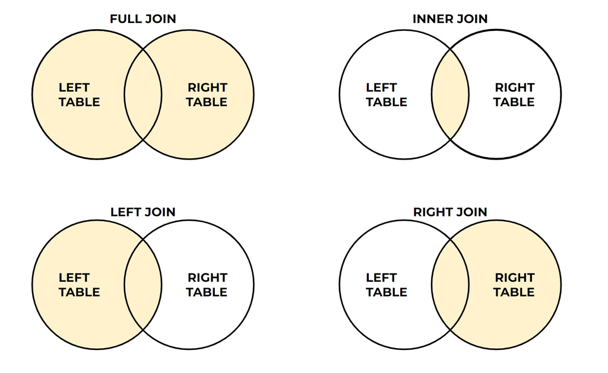

Es importante tener en cuenta que, para poder unir 2 set de datos ambos tienen que tener algo en común (alguna columna como por ejemplo un ID), sino sería imposible que R entienda que tiene que unir con qué. Por lo tanto, antes de unirlos deberemos manipularlos y realizarles diferentes tipos de transformaciones que nos permitan llegar a generar esta variable en común.

Por ejemplo en nuestro caso, si queremos unir algún dato a nuestro dataset espacial de partidos, deberíamos tener un valor único por cada nombre de partido (que funciona como el ID de mi dataset espacial).

Trabajemos con los [datos del Censo 2010](https://data.world/angie-scetta/censo2010-amba) y hagamos los pasos necesarios para que pueda unirse a partidos_amba.

*Recomendación: Al igual que en el dataset anterior, al descargar el csv deberán moverlo de la carpeta “Descargas” a la carpeta llamada “data” dentro del Proyecto donde están trabajando.*

```r
partidos_censo2010 <- read.csv("data/partidos_censo2010.csv", stringsAsFactors = TRUE, encoding="latin1")
```

Veamos que tenemos:

```r
summary(partidos_censo2010)
```

```
##      codigo                 nombre      pob_2010          viv_2010
##  Min.   :2001   Almirante Brown: 1   Min.   :  56729   Min.   : 19287
##  1st Qu.:2013   Avellaneda     : 1   1st Qu.: 174013   1st Qu.: 64864
##  Median :6319   Berazategui    : 1   Median : 223281   Median : 93389
##  Mean   :5075   Berisso        : 1   Mean   : 301108   Mean   :104104
##  3rd Qu.:6544   Comuna 1       : 1   3rd Qu.: 340723   3rd Qu.:123359
##  Max.   :6861   Comuna 10      : 1   Max.   :1775816   Max.   :447306
##                 (Other)        :42
##     hog_2010
##  Min.   : 17116
##  1st Qu.: 59537
##  Median : 81055
##  Mean   : 95612
##  3rd Qu.:109566
##  Max.   :484909
##
```

Bien, es un dataset tradicional con 5 variables o columnas: codigo, nombre, población 2010, cantidad de viviendas 2010 y cantidad de hogares 2010. Podemos analizar un poco los valores y ver por ejemplo que, en promedio los partidos de AMBA tienen 301.108 habitantes, y que el más poblado tiene 1.775.816 y el menos poblado 56.729.

Pero el detalle más importante es que hay una columna llamada “nombre” que tiene el nombre de nuestros partidos, y eso es una buena noticia ya que ella será quien nos permitirá unir ambos dataset (el espacial y el tradicional). Revisemos si los valores de esta columna están escritos de la misma forma en ambos dataset:

```r
head(partidos_amba$nombre)
```

```
## [1] AVELLANEDA TIGRE      PILAR      MORENO     MERLO      LA MATANZA
## 48 Levels: ALMIRANTE BROWN AVELLANEDA BERAZATEGUI BERISSO ... VICENTE LOPEZ
```

```r
head(partidos_censo2010$nombre)
```

```
## [1] Almirante Brown Avellaneda      Berazategui     Berisso
## [5] Comuna 1        Comuna 10
## 48 Levels: Almirante Brown Avellaneda Berazategui Berisso ... Vicente López
```

Podemos ver que:

- El dataset “partidos_amba” tiene los nombres de los partidos escritos completamente en mayúscula y sin tildes.
- El dataset “partidos_censo2010” tiene los nombres de los partidos solo con la primera letra en mayúscula y con tildes.

Editemos el dataset “partidos_censo2010” para que ambos objetos tengan escrito de la misma forma el nombre de los partidos así logramos que la unión sea exitosa.

- Primero eliminemos tildes con mutate() y str_replace_all():

```r
partidos_censo2010 <- partidos_censo2010 %>%
  mutate(nombre=str_replace_all(nombre, c("á"="a", "é"="e", "í"="i", "ó"="o", "ú"="u")))
```

- Y luego, pasemos las letras a mayúscula con mutate() y toupper():

```r
partidos_censo2010 <- partidos_censo2010 %>%
  mutate(nombre=toupper(nombre))
```

```r
head(partidos_censo2010$nombre)
```

```
## [1] "ALMIRANTE BROWN" "AVELLANEDA"      "BERAZATEGUI"     "BERISSO"
## [5] "COMUNA 1"        "COMUNA 10"
```

Ahora que ya tenemos los mismos valores en ambas variables utilicemos la función *left_join()* dejando del lado izquierdo al dataset espacial y del lado derecho al dataset tradicional:

```r
partidos_amba <- left_join(partidos_amba, partidos_censo2010, by="nombre")
```

Recuerden que, siempre que hagamos una unión entre dataset espacial y tradicional, el dataset espacial (dueño de la geometría) debe ser el que queda “intacto” y el dataset tradicional debe ser el que se “acopla”.

Veamos el resultado:

```r
summary(partidos_amba)
```

```
##     nombre          provincia    area_km2          codigo        pob_2010
##  Length:48          CABA:15   Min.   :  6.30   Min.   :2001   Min.   :  56729
##  Class :character   GBA :33   1st Qu.: 17.72   1st Qu.:2013   1st Qu.: 174013
##  Mode  :character             Median : 55.91   Median :6319   Median : 223281
##                               Mean   :140.59   Mean   :5075   Mean   : 301108
##                               3rd Qu.:177.07   3rd Qu.:6544   3rd Qu.: 340723
##                               Max.   :889.49   Max.   :6861   Max.   :1775816
##     viv_2010         hog_2010               geometry
##  Min.   : 19287   Min.   : 17116   MULTIPOLYGON :48
##  1st Qu.: 64864   1st Qu.: 59537   epsg:4326    : 0
##  Median : 93389   Median : 81055   +proj=long...: 0
##  Mean   :104104   Mean   : 95612
##  3rd Qu.:123359   3rd Qu.:109566
##  Max.   :447306   Max.   :484909
```

Efectivamente, se sumaron 4 nuevas columnas a mi dataset espacial: codigo, pob_2010, viv_2010 y hog_2010. ¿Qué esperamos? ¡Veamos alguna de ellas en un mapa!

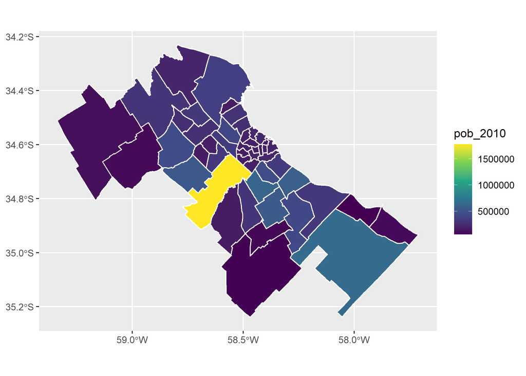

```r
ggplot(partidos_amba)+
  geom_sf(aes(fill=pob_2010), color="white")+
  scale_fill_viridis_c()
```

Cómo verán, hay un partido que resalta (el más poblado): La Matanza. Pero no nos quedemos con esa idea, ya que a mayor superficie es muy probable que haya mayor población, ¿No?. Entonces para que estos datos sean comparables entre todos los partidos, podríamos calcular una densidad relacionando la cantidad de habitantes y la superficie (km2) de cada uno.

También aprovechemos y mejoremos la estética agregando etiquetas (título, subtítulo, etc), cambiando el aspecto (theme) y ajustando los colores a las paletas de Brewer:

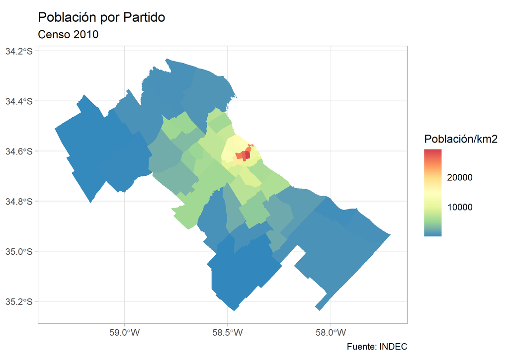

```r
ggplot(partidos_amba)+
  geom_sf(aes(fill=pob_2010/area_km2), color=NA)+
    labs(title = "Población por Partido",
         subtitle = "Censo 2010",
         fill = "Población/km2",
         caption= "Fuente: INDEC") +
  scale_fill_distiller(palette = "Spectral") +
  theme_light()
```

Ahora el panorama cambió un poco y vemos como algunas comunas de CABA son las más densas. Miremos CABA en detalle!

¿Cómo hacemos si queremos ver este mapa con un “zoom” solo de CABA? Tenemos que filtrar el dataset de la siguiente forma:

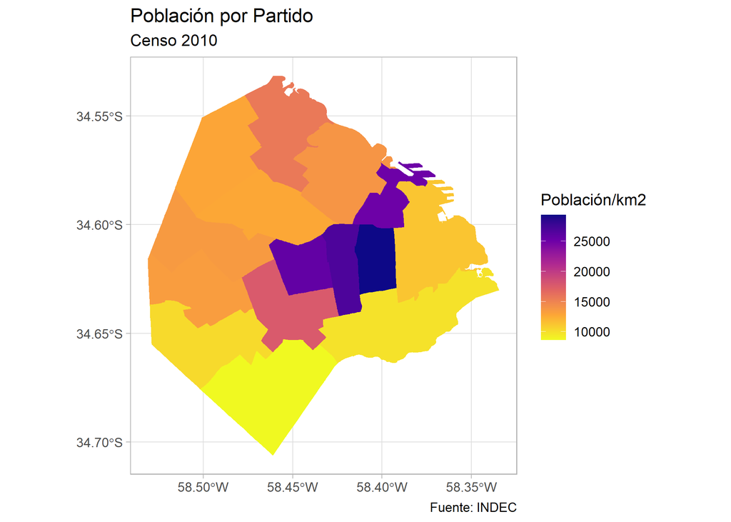

```r
ggplot(partidos_amba %>% filter(provincia=="CABA"))+
  geom_sf(aes(fill=pob_2010/area_km2), color=NA)+
    labs(title = "Población por Partido",
         subtitle = "Censo 2010",
         fill = "Población/km2",
         caption= "Fuente: INDEC") +
  scale_fill_viridis_c(option = "plasma", direction=-1) +
  theme_light()
```

Pongamos algunas etiquetas para poder diferenciar las comunas rápidamente!

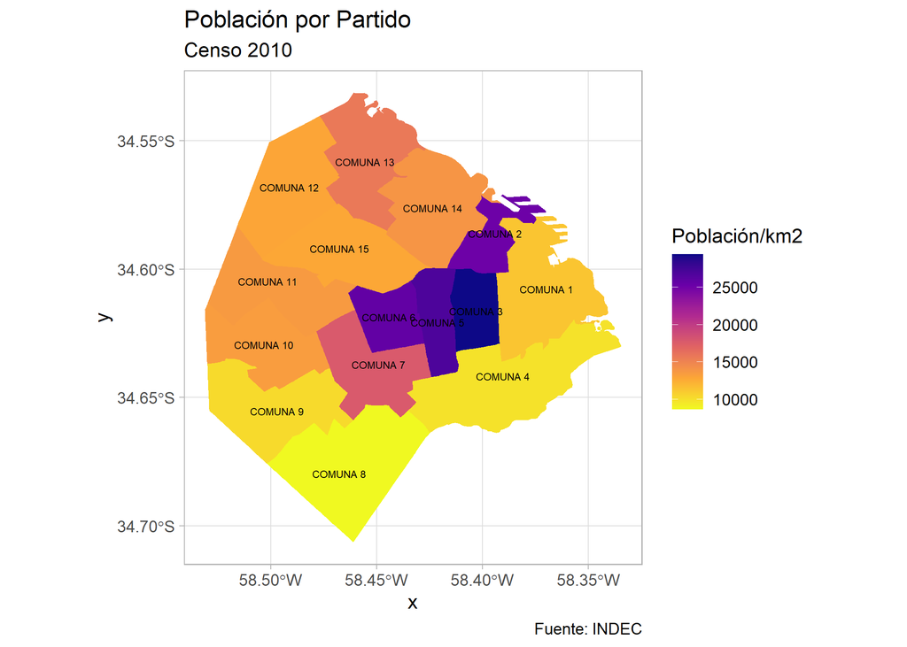

```r
ggplot(partidos_amba %>% filter(provincia=="CABA"))+
  geom_sf(aes(fill=pob_2010/area_km2), color=NA)+
  geom_sf_text(aes(label = nombre), size=2) +
    labs(title = "Población por Partido",
         subtitle = "Censo 2010",
         fill = "Población/km2",
         caption= "Fuente: INDEC") +
  scale_fill_viridis_c(option = "plasma", direction=-1) +
  theme_light()
```

La Comuna 3 es la que tiene la mayor densidad poblacional, y la Comuna 8 la menor.

Ahora probemos con la variable cantidad de viviendas por km2:

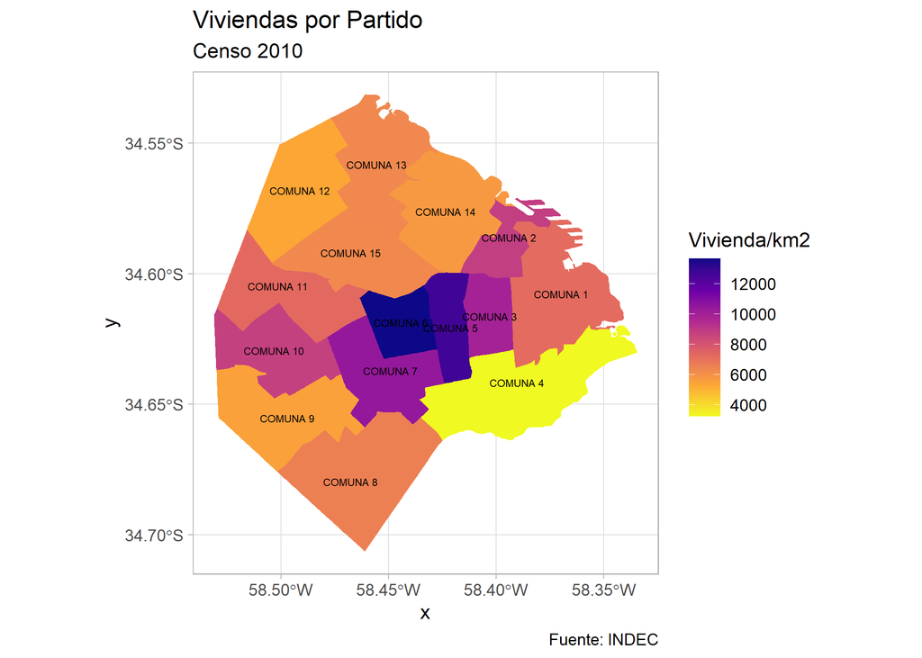

```r
ggplot(partidos_amba %>% filter(provincia=="CABA"))+
  geom_sf(aes(fill=viv_2010/area_km2), color=NA)+
  geom_sf_text(aes(label = nombre), size=2) +
    labs(title = "Viviendas por Partido",
         subtitle = "Censo 2010",
         fill = "Vivienda/km2",
         caption= "Fuente: INDEC") +
  scale_fill_viridis_c(option = "plasma", direction=-1) +
  theme_light()
```

Podemos ver que aparece la Comuna 6 con la mayor densidad de viviendas, seguida por la 5.

Hagamos un recorte del mapa y quedemonos solo con las Comunas que tienen más de 8.000 viviendas por km2:

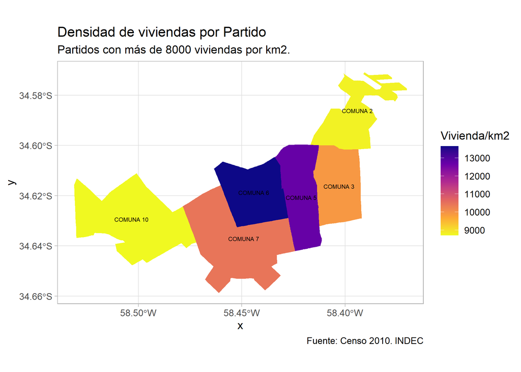

```r
ggplot(partidos_amba %>% filter(provincia=="CABA" & viv_2010/area_km2>=8000))+
  geom_sf(aes(fill=viv_2010/area_km2), color=NA)+
  geom_sf_text(aes(label = nombre), size=2) +
    labs(title = "Densidad de viviendas por Partido",
         subtitle = "Partidos con más de 8000 viviendas por km2.",
         fill = "Vivienda/km2",
         caption= "Fuente: Censo 2010. INDEC") +
  scale_fill_viridis_c(option = "plasma", direction=-1) +
  theme_light()
```

Y por último agreguémosle el mapa de fondo así las comunas no quedan flotando:

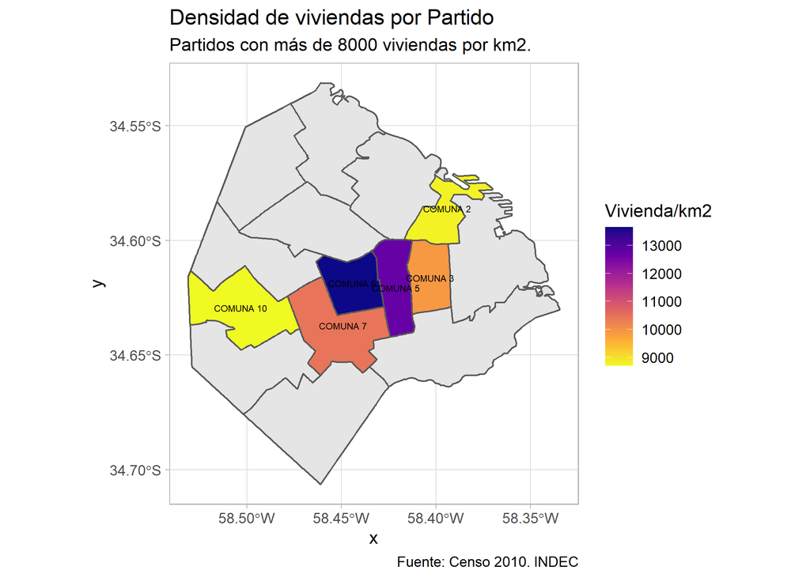

```r
ggplot()+
  geom_sf(data=partidos_amba %>% filter(provincia=="CABA"))+
  geom_sf(data=partidos_amba %>% filter(provincia=="CABA" & viv_2010/area_km2>=8000), aes(fill=viv_2010/area_km2))+
  geom_sf_text(data=partidos_amba %>% filter(provincia=="CABA" & viv_2010/area_km2>=8000), aes(label = nombre), size=2) +
    labs(title = "Densidad de viviendas por Partido",
         subtitle = "Partidos con más de 8000 viviendas por km2.",
         fill = "Vivienda/km2",
         caption= "Fuente: Censo 2010. INDEC") +
  scale_fill_viridis_c(option = "plasma", direction=-1) +
  theme_light()
```

```r
partidos_amba <- partidos_amba %>%
  mutate(CATEGORIA=as.factor(if_else(pob_2010>=300000, "MAYOR DE 300K", "MENOR DE 300K")))
```

```r
summary(partidos_amba)
```

```
##     nombre          provincia    area_km2          codigo        pob_2010
##  Length:48          CABA:15   Min.   :  6.30   Min.   :2001   Min.   :  56729
##  Class :character   GBA :33   1st Qu.: 17.72   1st Qu.:2013   1st Qu.: 174013
##  Mode  :character             Median : 55.91   Median :6319   Median : 223281
##                               Mean   :140.59   Mean   :5075   Mean   : 301108
##                               3rd Qu.:177.07   3rd Qu.:6544   3rd Qu.: 340723
##                               Max.   :889.49   Max.   :6861   Max.   :1775816
##     viv_2010         hog_2010               geometry          CATEGORIA
##  Min.   : 19287   Min.   : 17116   MULTIPOLYGON :48   MAYOR DE 300K:17
##  1st Qu.: 64864   1st Qu.: 59537   epsg:4326    : 0   MENOR DE 300K:31
##  Median : 93389   Median : 81055   +proj=long...: 0
##  Mean   :104104   Mean   : 95612
##  3rd Qu.:123359   3rd Qu.:109566
##  Max.   :447306   Max.   :484909
```

Excelente ya tenemos nuestra variable categórica que nos indica que 17 partidos tienen más de 300.000 habitantes y 31 tienen menos. A mapear!

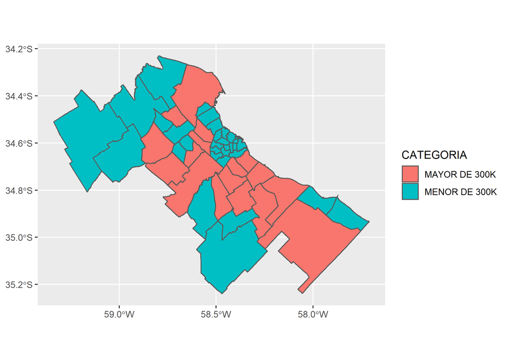

```r
ggplot(partidos_amba)+
  geom_sf(aes(fill=CATEGORIA))
```

Modifiquemos su estética como ya aprendimos:

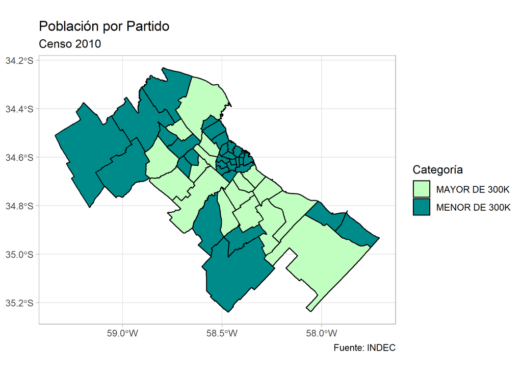

```r
ggplot(partidos_amba)+
  geom_sf(aes(fill=CATEGORIA), color="black") +
    labs(title = "Población por Partido",
         subtitle = "Censo 2010",
         fill = "Categoría",
         caption= "Fuente: INDEC") +
  scale_fill_manual(values=c("darkseagreen1", "cyan4"))+
  theme_light()
```

## Ejercicios de práctica

1. Elegir una ciudad de cualquier parte del mundo que les interese y que disponga de un portal de datos abiertos que ofrezca un dataset espacial (formato geojson o shp) de polígonos con alguna división geográfica: barrios, comunas, etc.

*Pueden elegir una ciudad de [esta planilla](https://docs.google.com/spreadsheets/d/14VgPW46aq9x8mJ0HXMtrktPrIyC6NxErY2so8VvLQp4/edit#gid=900051011), donde ya se han identificado portales con datos espaciales. Si eligen otra, por favor agreguen los datos a la planilla así crece de forma colaborativa.*

2. Realizar todas las transformaciones que sean necesarias para poder desarrollar al menos un ejemplo de cada uno de los siguientes mapas:
- Mapa coroplético que muestre la distribución geográfica de una variable numérica.
- Mapa coroplético que muestre la distribución geográfica de una variable categórica.